# Linear Regression and Clustering

Xu Yang

12/13/2017

# Function

This function is to caculate the distances between members of clusters, and plot the distances against the number of clusters.Then throuhg the plot we can choose the number of cluster to do clustering.

```r
wssplot <- function(data, nc=15, seed=1234){
  wss <- (nrow(data)-1)*sum(apply(data,2,var))
  for (i in 2:nc){
    set.seed(seed)
    wss[i] <- sum(kmeans(data, centers=i)$withinss)}

  plot(1:nc, wss, type="b", xlab="Number of Clusters",
       ylab="Within groups sum of squares")
}
```

# Load Data

Here we use the estimate employment data of Seattle_Bellevue_Everett area and Portland_Vancouver_Hillsborough area which covers years from 2008 to 2017.

We use 2008-2015 as traning data, and use 2016-2017 as test data.

```r
Seattle_VanPort_08_17<-read.table("Seattle_VanPort_08_17.csv",header = TRUE,sep=",",stringsAsFactors=FALSE)

Seattle_VanPort_08_17$SOC.CategoryCode<-factor(Seattle_VanPort_08_17$SOC.CategoryCode)
Seattle_VanPort_08_17$SOC.code<-factor(Seattle_VanPort_08_17$SOC.code)

Seattle_VanPort_08_15<-subset(Seattle_VanPort_08_17, Year < 2016)

Seattle_VanPort_16_17<-subset(Seattle_VanPort_08_17, Year > 2015)
```

# Correalations of Year, Employment and Anuual Wage

```r
Seattle_VanPort.Y_W_E<-data.frame("year"=Seattle_VanPort_08_15$Year,
                                  "wage"=Seattle_VanPort_08_15$ANNUAL.wage,
                                  "employment"=Seattle_VanPort_08_15$EST.employment)
cor(Seattle_VanPort.Y_W_E)
```

```
##                   year        wage   employment
## year       1.000000000  0.07961521  0.001993946
## wage       0.079615207  1.00000000 -0.059495697
## employment 0.001993946 -0.05949570  1.000000000
```

It looks like there less correlation between Year,EST.employment and ANNUAL.wage.

Let’s do a linear regression to use Year+EST.employment against ANNUAL.wage

# Linear Regression: Annual Wage against Year&Employment

```r
employ.mod1<- lm(ANNUAL.wage ~ Year+EST.employment,data=na.omit(Seattle_VanPort_08_15))
summary(employ.mod1)
```

```
##
## Call:
## lm(formula = ANNUAL.wage ~ Year + EST.employment, data = na.omit(Seattle_VanPort_08_15))
##
## Residuals:
##    Min     1Q Median     3Q    Max
## -40198 -19739  -6883  12387 200951
##
## Coefficients:
##                  Estimate Std. Error t value Pr(>|t|)
## (Intercept)    -2.085e+06  2.715e+05  -7.679 1.77e-14 ***
## Year            1.065e+03  1.350e+02   7.890 3.38e-15 ***
## EST.employment -4.816e-01  8.110e-02  -5.939 2.98e-09 ***
## ---
## Signif. codes:  0 '***' 0.001 '**' 0.01 '*' 0.05 '.' 0.1 ' ' 1
##
## Residual standard error: 29140 on 9287 degrees of freedom
## Multiple R-squared:  0.01037,    Adjusted R-squared:  0.01016
## F-statistic: 48.65 on 2 and 9287 DF,  p-value: < 2.2e-16
```

The Year and EST.employment are both significant, but R-squared and Adjusted R-squared all are quite small,near around 0.01.

We can try some category variables. Let’s try occupation category at first

# Linear Regression: Annual Wage against Occupation Categories

```r
employ.mod2<- lm(ANNUAL.wage ~ SOC.CategoryCode,data=na.omit(Seattle_VanPort_08_15))
summary(employ.mod2)
```

```
##
## Call:
## lm(formula = ANNUAL.wage ~ SOC.CategoryCode, data = na.omit(Seattle_VanPort_08_15))
##
## Residuals:
##    Min     1Q Median     3Q    Max
## -66089 -10672  -2204   8548 169115
##
## Coefficients:
##                    Estimate Std. Error t value Pr(>|t|)
## (Intercept)        100821.5      995.4 101.284   <2e-16 ***
## SOC.CategoryCode13 -34241.0     1466.3 -23.351   <2e-16 ***
## SOC.CategoryCode15 -16211.2     1798.1  -9.016   <2e-16 ***
## SOC.CategoryCode17 -28124.5     1478.1 -19.027   <2e-16 ***
## SOC.CategoryCode19 -31828.6     1415.2 -22.491   <2e-16 ***
## SOC.CategoryCode21 -53786.1     1707.8 -31.494   <2e-16 ***
## SOC.CategoryCode23 -27701.4     2391.6 -11.583   <2e-16 ***
## SOC.CategoryCode25 -36334.7     1290.9 -28.147   <2e-16 ***
## SOC.CategoryCode27 -45654.1     1430.9 -31.905   <2e-16 ***
## SOC.CategoryCode29 -11619.5     1291.3  -8.998   <2e-16 ***
## SOC.CategoryCode31 -64269.7     1786.6 -35.974   <2e-16 ***
## SOC.CategoryCode33 -44379.1     1701.1 -26.089   <2e-16 ***
## SOC.CategoryCode35 -74540.0     1681.6 -44.326   <2e-16 ***
## SOC.CategoryCode37 -65257.4     2222.2 -29.366   <2e-16 ***
## SOC.CategoryCode39 -69877.1     1550.5 -45.068   <2e-16 ***
## SOC.CategoryCode41 -47391.2     1600.6 -29.608   <2e-16 ***
## SOC.CategoryCode43 -62147.2     1258.4 -49.388   <2e-16 ***
## SOC.CategoryCode45 -62178.6     2401.5 -25.892   <2e-16 ***
## SOC.CategoryCode47 -50147.2     1397.8 -35.876   <2e-16 ***
## SOC.CategoryCode49 -51451.3     1373.1 -37.472   <2e-16 ***
## SOC.CategoryCode51 -61945.4     1177.8 -52.593   <2e-16 ***
## SOC.CategoryCode53 -54400.2     1420.6 -38.295   <2e-16 ***
## ---
## Signif. codes:  0 '***' 0.001 '**' 0.01 '*' 0.05 '.' 0.1 ' ' 1
##
## Residual standard error: 21850 on 9268 degrees of freedom
## Multiple R-squared:  0.4444, Adjusted R-squared:  0.4431
## F-statistic:   353 on 21 and 9268 DF,  p-value: < 2.2e-16
```

All categories are significant. R-squared is up to 0.4444, and Adjusted R-squared is up to 0.4431. We have improvement but this model is not good enough yet.

How about using occupation code?

# Linear Regression: Annual Wage against Occupation Codes

```r
employ.mod3<- lm(ANNUAL.wage ~ SOC.code,data=na.omit(Seattle_VanPort_08_15))
summary(employ.mod3)
```

```
##
## Call:
## lm(formula = ANNUAL.wage ~ SOC.code, data = na.omit(Seattle_VanPort_08_15))
##
## Residuals:
##    Min     1Q Median     3Q    Max
## -93990  -3066   -118   2928  51254
##
## Coefficients:
##                 Estimate Std. Error t value Pr(>|t|)
## (Intercept)       207054       1761 117.578  < 2e-16 ***
## SOC.code11-1021   -80585       2490 -32.358  < 2e-16 ***
## SOC.code11-1031  -135454       2532 -53.506  < 2e-16 ***
## SOC.code11-2011  -101681       2630 -38.659  < 2e-16 ***
## SOC.code11-2021   -86563       2490 -34.759  < 2e-16 ***
## SOC.code11-2022   -83622       2490 -33.578  < 2e-16 ***
## SOC.code11-2031  -108286       2490 -43.481  < 2e-16 ***
## SOC.code11-3011  -115892       2490 -46.535  < 2e-16 ***
## SOC.code11-3021   -78219       2490 -31.408  < 2e-16 ***
## SOC.code11-3031   -93234       2490 -37.437  < 2e-16 ***
## SOC.code11-3041  -104234       3938 -26.471  < 2e-16 ***
## SOC.code11-3042  -113656       3609 -31.493  < 2e-16 ***
## SOC.code11-3049   -99603       3372 -29.538  < 2e-16 ***
## SOC.code11-3051  -104718       2490 -42.049  < 2e-16 ***
## SOC.code11-3061  -103352       2532 -40.825  < 2e-16 ***
## SOC.code11-3071  -111814       2490 -44.898  < 2e-16 ***
## SOC.code11-3111   -96568       2840 -34.009  < 2e-16 ***
## SOC.code11-3121   -94898       2935 -32.333  < 2e-16 ***
## SOC.code11-3131  -102624       2840 -36.141  < 2e-16 ***
## SOC.code11-9013  -134252       3938 -34.094  < 2e-16 ***
## SOC.code11-9021  -104771       2490 -42.070  < 2e-16 ***
## SOC.code11-9031  -159329       2630 -60.577  < 2e-16 ***
## SOC.code11-9032  -107863       2490 -43.311  < 2e-16 ***
## SOC.code11-9033  -112181       2532 -44.313  < 2e-16 ***
## SOC.code11-9039  -135108       2578 -52.412  < 2e-16 ***
## SOC.code11-9041   -74359       2532 -29.373  < 2e-16 ***
## SOC.code11-9051  -149396       2690 -55.539  < 2e-16 ***
## SOC.code11-9061  -141263       3609 -39.142  < 2e-16 ***
## SOC.code11-9071  -121821       3050 -39.940  < 2e-16 ***
## SOC.code11-9081  -145741       2490 -58.521  < 2e-16 ***
```

[output cut: 772 more lines]

```
## SOC.code53-7051  -168596       2490 -67.698  < 2e-16 ***
## SOC.code53-7061  -181023       2490 -72.688  < 2e-16 ***
## SOC.code53-7062  -178059       2490 -71.498  < 2e-16 ***
## SOC.code53-7063  -179052       2532 -70.728  < 2e-16 ***
## SOC.code53-7064  -182394       2490 -73.238  < 2e-16 ***
## SOC.code53-7071  -163969       7261 -22.583  < 2e-16 ***
## SOC.code53-7081  -161288       2578 -62.568  < 2e-16 ***
## SOC.code53-7121  -149742       2578 -58.088  < 2e-16 ***
## SOC.code53-7199  -163820       2630 -62.285  < 2e-16 ***
## ---
## Signif. codes:  0 '***' 0.001 '**' 0.01 '*' 0.05 '.' 0.1 ' ' 1
##
## Residual standard error: 7044 on 8479 degrees of freedom
## Multiple R-squared:  0.9472, Adjusted R-squared:  0.9421
## F-statistic: 187.8 on 810 and 8479 DF,  p-value: < 2.2e-16
```

All occupation codes are significant. R-squared is up to 0.9472, and Adjusted R-squared is up to 0.9421. It looks like a good model.Can we use it to do predicting?

```r
predict(employ.mod3,newdata =Seattle_VanPort_16_17 )
```

```
## Error in model.frame.default(Terms, newdata, na.action = na.action, xlev = object$xlevels): factor SOC.code has new levels 25-1031, 25-1043, 27-2011, 27-2042, 27-2099, 39-5091, 49-9063, 51-6063
```

Oh, here is a error that SOC.code has new levels.That means test data has some occupation codes which are not in the training data.

How about “Computer and Mathmatical” occupation category? Let’s make the training data and test data for this category, and do linear regression for the new train data.

# Linear Regression under “Computer and Mathmatical” occupation category

```r
computer_train<-Seattle_VanPort_08_15[Seattle_VanPort_08_15$SOC.CategoryName=="Computer and Mathematical",]
computer_train$SOC.code<-factor(computer_train$SOC.code)

computer_test<-Seattle_VanPort_16_17[Seattle_VanPort_16_17$SOC.CategoryName=="Computer and Mathematical",]
computer_test$SOC.code<-factor(computer_test$SOC.code)

employ.mod4<- lm(ANNUAL.wage ~ SOC.code,data=na.omit(computer_train))
summary(employ.mod4)
```

```
##
## Call:
## lm(formula = ANNUAL.wage ~ SOC.code, data = na.omit(computer_train))
##
## Residuals:
##    Min     1Q Median     3Q    Max
## -27640  -5992   -138   6030  32451
##
## Coefficients:
##                 Estimate Std. Error t value Pr(>|t|)
## (Intercept)       112281       5639  19.910  < 2e-16 ***
## SOC.code15-1021   -32335       6907  -4.682 5.57e-06 ***
## SOC.code15-1031   -24228       6907  -3.508 0.000570 ***
## SOC.code15-1032   -20711       7460  -2.776 0.006077 **
## SOC.code15-1041   -63198       6907  -9.150  < 2e-16 ***
## SOC.code15-1051   -30672       6907  -4.441 1.56e-05 ***
## SOC.code15-1061   -36678       6907  -5.310 3.18e-07 ***
## SOC.code15-1071   -39330       6907  -5.694 4.92e-08 ***
## SOC.code15-1081   -33154       6907  -4.800 3.31e-06 ***
## SOC.code15-1099   -33364       6907  -4.831 2.89e-06 ***
## SOC.code15-1111    -4743       6740  -0.704 0.482502
## SOC.code15-1121   -20221       6430  -3.145 0.001942 **
## SOC.code15-1122   -22942       6907  -3.322 0.001082 **
## SOC.code15-1131   -23300       6430  -3.624 0.000377 ***
## SOC.code15-1132   -12295       6430  -1.912 0.057428 .
## SOC.code15-1133    -7638       6430  -1.188 0.236457
## SOC.code15-1134   -33769       6907  -4.889 2.22e-06 ***
## SOC.code15-1141   -25857       6430  -4.021 8.48e-05 ***
## SOC.code15-1142   -34871       6430  -5.423 1.85e-07 ***
## SOC.code15-1143     7188       6907   1.041 0.299395
## SOC.code15-1150   -55437       8917  -6.217 3.40e-09 ***
## SOC.code15-1151   -56932       6907  -8.243 3.32e-14 ***
## SOC.code15-1152   -44658       6907  -6.466 9.08e-10 ***
## SOC.code15-1179   -32433       7460  -4.347 2.29e-05 ***
## SOC.code15-1199   -30461       6907  -4.410 1.77e-05 ***
## SOC.code15-1799   -29947       7975  -3.755 0.000233 ***
## SOC.code15-2011   -16696       6305  -2.648 0.008811 **
## SOC.code15-2021    -4068       7975  -0.510 0.610593
## SOC.code15-2031   -31486       6362  -4.949 1.70e-06 ***
## SOC.code15-2041   -39209       6214  -6.309 2.09e-09 ***
## SOC.code15-2091   -53210       7975  -6.672 2.97e-10 ***
## SOC.code15-2099   -30322       7975  -3.802 0.000196 ***
## ---
## Signif. codes:  0 '***' 0.001 '**' 0.01 '*' 0.05 '.' 0.1 ' ' 1
##
## Residual standard error: 9768 on 181 degrees of freedom
## Multiple R-squared:   0.73,  Adjusted R-squared:  0.6837
## F-statistic: 15.78 on 31 and 181 DF,  p-value: < 2.2e-16
```

There are some levels that are not significant. And the R-squared is down to 0.73, Adjusted R-squared is down to 0.6837.

This time let’s see if we can do predicting.

```r
predictWage_computer = predict(employ.mod4,newdata =computer_test )
SSE=sum( (computer_test$ANNUAL.wage-predictWage_computer)^2)
SST=sum( (computer_test$ANNUAL.wage-mean(computer_train$ANNUAL.wage))^2 )
Rsquared_computer=1-SSE/SST
print(paste("R-squared for predictWage_computer is: ", Rsquared_computer))
```

```
## [1] "R-squared for predictWage_computer is:  0.586625210361822"
```

We can do predicting for “Computer and Mathmatical” category.The R-squared for the prediction is 0.5866,and it is no so high as that for all occupation categories.

It seems there something need to be digged out between annual wage and occupation code. Maybe companies’ revenue,profit, or some economic data of industries. This can be done in another project. Here let’s see clustering.

# Clustering under “Computer and Mathmatical” occupation category

We do some plot for choosing the number of clusters.

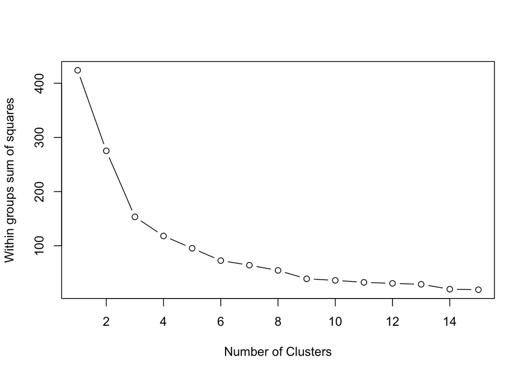

```r
employ.wage<-scale(computer_train[c(3,4)])

wssplot(employ.wage)
```

From the plot we can see a bent when number of clusters is 3. Then we choose 3 as the number of clusters.

```r
set.seed(1234)
employ.km <- kmeans(employ.wage,centers=3,nstart=15)

tapply(computer_train$ANNUAL.wage,employ.km$cluster,mean)
```

```
##         1         2         3
##  71382.39 102228.65  98443.18
```

```r
tapply(computer_train$EST.employment,employ.km$cluster,mean)
```

```
##         1         2         3
##  2328.036 30984.500  4485.653
```

Now,we can see the average annual wage and employment for three clusters. Cluster 1 has lowest aveage annual wage and employment. Cluster 2 has highest average anuual wage and employment.

Then what kind of occupation titles are in the three clusters? We can put them together and have a look.

```r
computer_train$cluster<-employ.km$cluster

tidy_computer<-data.frame("SOC.title"=computer_train$SOC.title,"Employment"=computer_train$EST.employment,
                          "Anuual.Wage"=computer_train$ANNUAL.wage,"Year"=computer_train$Year,
                          "Cluster"=computer_train$cluster)

tidy_computer[tidy_computer$Cluster==1,]
```

```
##                                                    SOC.title Employment Anuual.Wage Year Cluster
## 1                                       Computer Programmers        390    65918.00 2008       1
## 2                  Computer Software Engineers, Applications        280    77805.00 2008       1
## 3              Computer Software Engineers, Systems Software        100    71901.00 2008       1
## 4                               Computer Support Specialists        530    45005.00 2008       1
## 5                                  Computer Systems Analysts        230    76266.00 2008       1
## 6                                    Database Administrators         50    62281.00 2008       1
## 7                  Network & Computer Systems Administrators        280    65788.00 2008       1
## 8             Network Systems & Data Communications Analysts        110    64455.00 2008       1
## 9                            Computer Specialists, All Other        110    78873.00 2008       1
## 10                                      Computer Programmers        263    68088.00 2009       1
## 11                 Computer Software Engineers, Applications        303    75924.00 2009       1
## 12                              Computer Support Specialists        535    45834.00 2009       1
## 13                                 Computer Systems Analysts        231    77046.00 2009       1
## 14                                   Database Administrators         25    69387.00 2009       1
```

[output cut: 96 more lines]

As a pre-data-scientist, I certainly care about statisticians. Statisticians appeared from 2010 to 2014 in cluster 1, and it’s annual wage has a upgrowing trend.But in 2015, there is no statisticians in cluster 1.

How about cluster 2?

```r
tidy_computer[tidy_computer$Cluster==2,]
```

```
##                                     SOC.title Employment Anuual.Wage Year Cluster
## 108 Computer Software Engineers, Applications      22170     91215.0 2008       2
## 121 Computer Software Engineers, Applications      21253     95245.0 2009       2
## 132 Computer Software Engineers, Applications      21726     96022.0 2010       2
## 145 Computer Software Engineers, Applications      23626     98074.0 2011       2
## 155 Computer Software Engineers, Applications      29705    100559.0 2012       2
## 168 Computer Software Engineers, Applications      35649    103299.2 2013       2
## 185         Software Developers, Applications      48435    114314.0 2014       2
## 201         Software Developers, Applications      45312    119101.0 2015       2
```

There are just software engineers and developers in the cluster2. Those guys have highest annual wage and great job opportunities!

Finally let’s take a look on cluster 3.

```r
tidy_computer[tidy_computer$Cluster==3,]
```

```
##                                                    SOC.title Employment Anuual.Wage Year Cluster
## 18               Computer & Information Scientists, Research         67   103847.00 2010       3
## 20                 Computer Software Engineers, Applications       7276    92112.00 2010       3
## 21             Computer Software Engineers, Systems Software       2055    97060.00 2010       3
## 32               Computer & Information Scientists, Research         44    96725.00 2011       3
## 35                 Computer Software Engineers, Applications       6765    93854.00 2011       3
## 36             Computer Software Engineers, Systems Software       1889   101531.00 2011       3
## 41                                                 Actuaries        213    91311.00 2011       3
## 45               Computer & Information Scientists, Research         21   108000.00 2012       3
## 46                                 Computer Systems Analysts       2957    86004.00 2012       3
## 48                 Computer Software Engineers, Applications       6366    93994.00 2012       3
## 49             Computer Software Engineers, Systems Software       1996    94033.00 2012       3
## 55                                                 Actuaries        121   106121.00 2012       3
## 59                                 Computer Systems Analysts       3428    88562.76 2013       3
## 62                 Computer Software Engineers, Applications       5740    92319.36 2013       3
```

[output cut: 81 more lines]

Oh, I found statisticians again! They jump up to cluster 3 in 2015 because they got higher annual wage.

Congratulation!